# Brownlows Bets

Arlene Faye Salvador

Year 2020

### 0.0.1 2020-11-13

# 1 Introduction

At the first day of class there are 35 students in Math Statistics class and professor Brownlow always proposes this bet to his students "I will wager $2 to your bet of $1 that at least two people in today’s class have the same birthday. He tells me he has made that bet 637 times so far. Where do you think his profits are? Discuss this in a markdown document

1. What are the fair odds for a bet on matching birthdays in a 35 person class?
2. For what size class is a 2:1 odds bet fair.
3. How much money would Brownlow be expected to end up with if the bets went as described.

# 2 Methods

Will solve this problem by resampling. Wills set up days of the year, take a random sample of 35, and see it two or more have the same birthday.

```r
daysYEAR=1:365
bDAYS=sample(daysYEAR,35,replace=TRUE)
length(unique(bDAYS))
```

```
## [1] 33
```

```r
bank=0
for(i in 1:637){
  class= sample(daysYEAR,35,replace=TRUE)
  n=length(unique(class))
  if(n == 35)bank=bank-2
  else bank =bank+1
}
print(bank)
```

```
## [1] 304
```

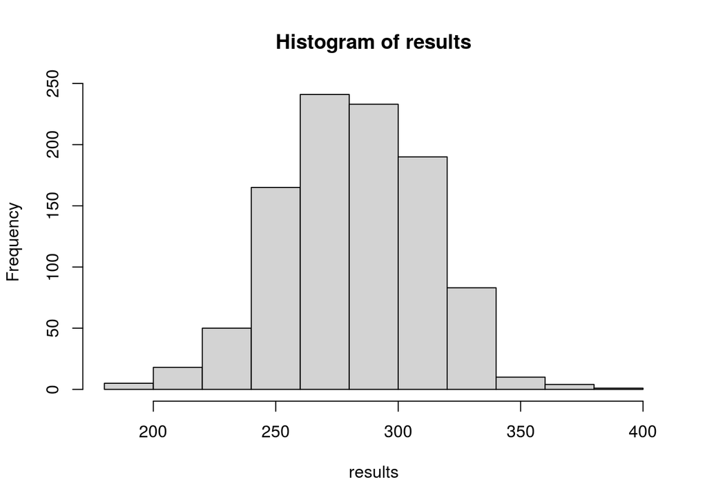

```r
results=vector("numeric")
for(j in 1:1000){
  bank=0
for(i in 1:637){
  class= sample(daysYEAR,35,replace=TRUE)
  n=length(unique(class))
  if(n == 35)bank=bank-2
  else bank =bank +1
}
results[j]=bank
}
hist(results)
```

# 3 Profit Estimate

```r
favstats(results)
```

```
##  min  Q1 median  Q3 max    mean       sd    n missing
##  184 262    283 304 385 281.995 29.80912 1000       0
```

# 4 Confidence interval of Brownlows earning

# 5 95% Confidence interval

```r
results=vector("numeric")
for(j in 1:1000){
  bank=0
for(i in 1:637){
  class= sample(daysYEAR,35,replace=TRUE)
  n=length(unique(class))
  if(n == 35)bank=bank-2
  else bank =bank +1
}
results[j]=bank
}
sortRESULTS=sort(results)
lcl=sortRESULTS[25]
ucl=sortRESULTS[975]
```

lower confidence limit= 226 upper confidence limit= 337